# Graficando

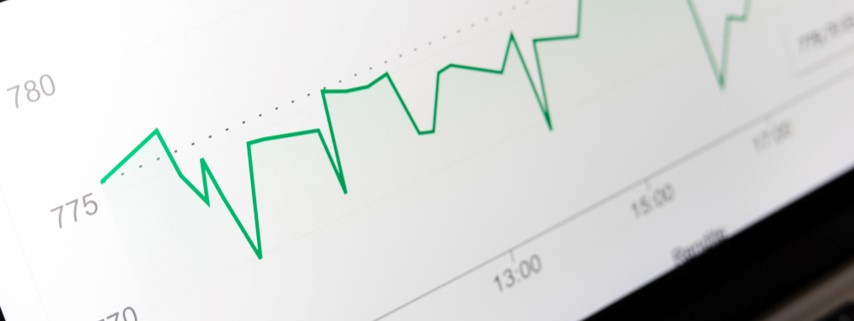

# Scatter plots

## Con tres (3) variables cuantitivas

Agregaremos una linea de ajuste usando el modelo lineal general + los respectibos intervalos de confianza de las bandas.

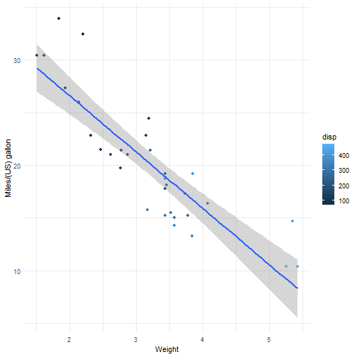

¿La relación entre x e y es igual entre los distintos sujetos en estudio? ¿qué sucede al tomar en cuenta otra varible, por ejemplo, cualitativa?  
Veamos

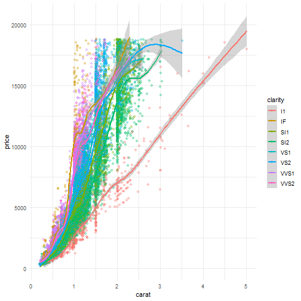

Se puede controlar el tamaño del punto ploteado, el color y el relleno de acuerdo a los valores que tomen ciertas variables

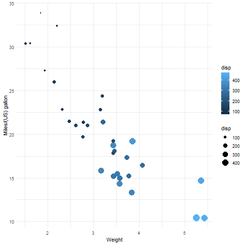

En ocasiones cuando una o las dos variables a graficar son categóricas,podemos presenciar overplotting, causando que no dimensionemos claramente el fenómeno estudiado. Para resolver lo anterior, podemos introducir un pequeño ruido en la representación de los puntos y aplicar un alpha (valor que regula la transparencia de los markers) y así lograr ver mejor la relación entre las variables.

Veamos sin jitter ni alpha

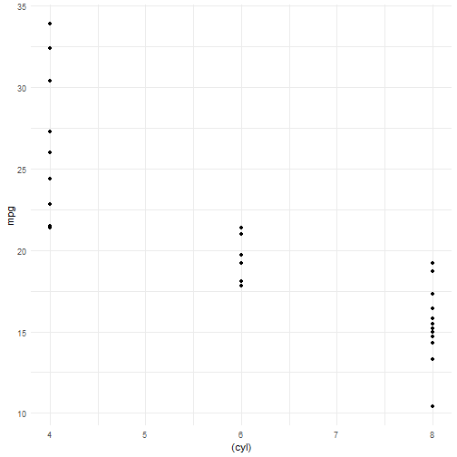

Notemos que aunque `cyl` es una variable discreta, R le da un tratamiento continuo y por eso vemos espacios entre 4 y 5 o 6 y 8, lo cual no tiene sentido. Reparemos esto, además de agregar jitter y opacidad a los puntos.

Con jitter y alpha = 0.2

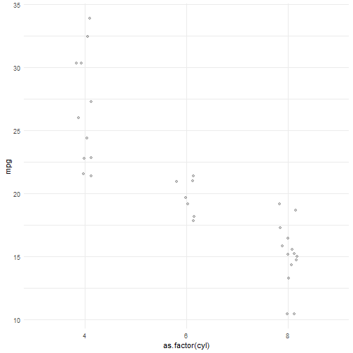

Podemos usar una variable cuantitativa como size y así enriquecer nuestro gráfico, además que la forma cambie de acuerdo al valor de una variable (discreta)

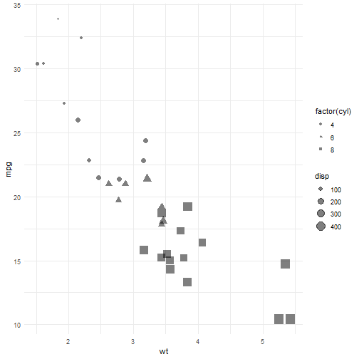

# Gráficos dinámicos

Un gráfico hecho con ggplot puede ser convertido en uno dinámico con la función `ggplotly()` de la librería `plotly`

[interactive chart not shown]

Styled with knitrBootstrap